# decision-tree-CART

```python
import pandas as pd
import numpy as np
import matplotlib.pyplot as plt
import itertools

from sklearn.tree import DecisionTreeClassifier, plot_tree
from sklearn.model_selection import cross_val_score
from sklearn.metrics import classification_report
from sklearn.metrics import confusion_matrix, roc_curve
```

```python
def plot_confusion_matrix(cm,
                          target_names,
                          title='Confusion matrix',
                          cmap=None,
                          normalize=True):
    """
        https://stackoverflow.com/a/50386871
    """

    accuracy = np.trace(cm) / float(np.sum(cm))
    misclass = 1 - accuracy

    if cmap is None:
        cmap = plt.get_cmap('Blues')

    plt.figure(figsize=(8, 6))
    plt.imshow(cm, interpolation='nearest', cmap=cmap)
    plt.title(title)
    plt.colorbar()

    if target_names is not None:
        tick_marks = np.arange(len(target_names))
        plt.xticks(tick_marks, target_names, rotation=45)
        plt.yticks(tick_marks, target_names)

    if normalize:
        cm = cm.astype('float') / cm.sum(axis=1)[:, np.newaxis]


    thresh = cm.max() / 1.5 if normalize else cm.max() / 2
    for i, j in itertools.product(range(cm.shape[0]), range(cm.shape[1])):
        if normalize:
            plt.text(j, i, "{:0.4f}".format(cm[i, j]),
                     horizontalalignment="center",
                     color="white" if cm[i, j] > thresh else "black")
        else:
            plt.text(j, i, "{:,}".format(cm[i, j]),
                     horizontalalignment="center",
                     color="white" if cm[i, j] > thresh else "black")


    plt.tight_layout()
    plt.ylabel('True label')
    plt.xlabel('Predicted label\naccuracy={:0.4f}; misclass={:0.4f}'.format(accuracy, misclass))
    plt.show()
```

```python
from sklearn.tree._tree import TREE_LEAF
#https://stackoverflow.com/a/49496027

def prune_index(inner_tree, index, threshold):
    if inner_tree.value[index].min() < threshold:
        # turn node into a leaf by "unlinking" its children
        inner_tree.children_left[index] = TREE_LEAF
        inner_tree.children_right[index] = TREE_LEAF
    # if there are shildren, visit them as well
    if inner_tree.children_left[index] != TREE_LEAF:
        prune_index(inner_tree, inner_tree.children_left[index], threshold)
        prune_index(inner_tree, inner_tree.children_right[index], threshold)
```

```python
full_set = pd.read_pickle("../../data/processed/full_set.pkl")

train_real_set = pd.read_pickle("../../data/processed/train_real_set.pkl")
test_real_set = pd.read_pickle("../../data/processed/test_real_set.pkl")

train_real_set_70 = pd.read_pickle("../../data/processed/train_real_set_70.pkl")
test_real_set_70 = pd.read_pickle("../../data/processed/test_real_set_70.pkl")


train_set = pd.read_pickle("../../data/processed/train_set.pkl")
test_set = pd.read_pickle("../../data/processed/test_set.pkl")

train_set_30 = pd.read_pickle("../../data/processed/train_set_30.pkl")
test_set_30 = pd.read_pickle("../../data/processed/test_set_30.pkl")

train_set_70 = pd.read_pickle("../../data/processed/train_set_70.pkl")
test_set_70 = pd.read_pickle("../../data/processed/test_set_70.pkl")
```

# Decision Tree classifiers

## Cross validation

```python
clf = DecisionTreeClassifier(random_state=42)
scores = cross_val_score(clf, full_set.iloc[:,0:2303], full_set['target'], cv=10)
np.mean(scores)
```

```
0.9106
```

## Train/test - default parameters

```
              precision    recall  f1-score   support

           0       0.76      0.80      0.78       335
           1       0.76      0.71      0.73       350
           2       0.91      0.96      0.94       339
           3       0.88      0.93      0.90       332
           4       0.89      0.84      0.86       324
           5       0.89      0.91      0.90       308
           6       0.93      0.90      0.91       338
           7       0.97      0.97      0.97       316
           8       0.90      0.88      0.89       322
           9       0.98      0.99      0.98       336

    accuracy                           0.89      3300
   macro avg       0.89      0.89      0.89      3300
weighted avg       0.89      0.89      0.89      3300
```

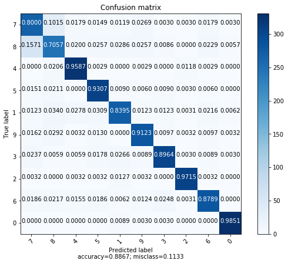

```python
clf = DecisionTreeClassifier(random_state=42)
clf.fit(train_set.iloc[:,0:2303], train_set['target'])
y_pred = clf.predict(test_set.iloc[:, 0:2303])
conf_mat = confusion_matrix(test_set["target"], y_pred)
print(classification_report(test_set["target"], y_pred))
plot_confusion_matrix(conf_mat, target_names=test_set['target'].unique())


# y_pred_rf = clf.predict_proba(test_set.iloc[:, 0:2303])[:,1]
# fpr_rf, tpr_rf, _ = roc_curve(test_set['target'], y_pred_rf)

# plt.figure(2)
# plt.plot([0, 1], [0, 1], 'k--')
# plt.plot(fpr_rf, tpr_rf, label='RF')
# plt.xlabel('False positive rate')
# plt.ylabel('True positive rate')
# plt.title('ROC curve')
# plt.legend(loc='best')
# plt.show()
```

## Train/test - Gini ration to Information Gain(entropy)

```
              precision    recall  f1-score   support

           0       0.81      0.76      0.78       335
           1       0.80      0.83      0.81       350
           2       0.94      0.97      0.95       339
           3       0.95      0.91      0.93       332
           4       0.86      0.88      0.87       324
           5       0.87      0.89      0.88       308
           6       0.95      0.92      0.94       338
           7       0.96      0.98      0.97       316
           8       0.94      0.91      0.92       322
           9       0.96      0.98      0.97       336

    accuracy                           0.90      3300
   macro avg       0.90      0.90      0.90      3300
weighted avg       0.90      0.90      0.90      3300
```

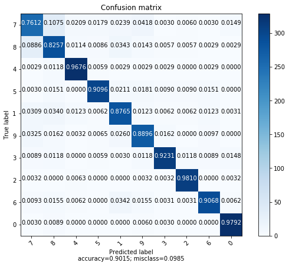

```python
clf = DecisionTreeClassifier(criterion="entropy",random_state=42)
clf.fit(train_set.iloc[:,0:2303], train_set['target'])
y_pred = clf.predict(test_set.iloc[:, 0:2303])
conf_mat = confusion_matrix(test_set["target"], y_pred)
print(classification_report(test_set["target"], y_pred))
plot_confusion_matrix(conf_mat, target_names=test_set['target'].unique())
```

# Post-Pruning

```
              precision    recall  f1-score   support

           0       0.76      0.80      0.78       335
           1       0.76      0.71      0.73       350
           2       0.91      0.96      0.94       339
           3       0.88      0.93      0.90       332
           4       0.89      0.84      0.86       324
           5       0.89      0.91      0.90       308
           6       0.93      0.90      0.91       338
           7       0.97      0.97      0.97       316
           8       0.90      0.88      0.89       322
           9       0.98      0.99      0.98       336

    accuracy                           0.89      3300
   macro avg       0.89      0.89      0.89      3300
weighted avg       0.89      0.89      0.89      3300
```

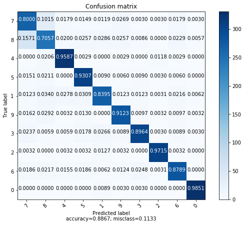

```
22 384
384
```

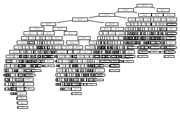

```
              precision    recall  f1-score   support

           0       0.36      0.76      0.49       335
           1       0.71      0.07      0.12       350
           2       0.66      0.70      0.68       339
           3       0.94      0.71      0.81       332
           4       0.45      0.79      0.58       324
           5       0.91      0.56      0.69       308
           6       0.94      0.81      0.87       338
           7       0.97      0.90      0.93       316
           8       0.73      0.73      0.73       322
           9       0.98      0.86      0.92       336

    accuracy                           0.69      3300
   macro avg       0.77      0.69      0.68      3300
weighted avg       0.76      0.69      0.68      3300
```

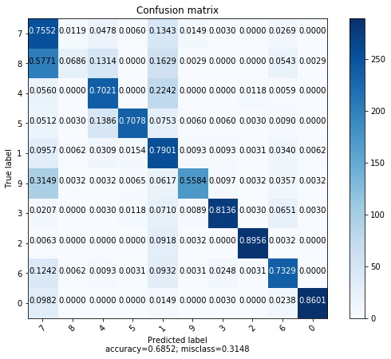

```
22 389
389
```

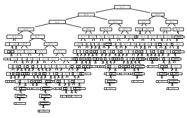

```python
from sklearn.tree import plot_tree
clf = DecisionTreeClassifier(random_state=42)
clf.fit(train_set.iloc[:,0:2303], train_set['target'])
y_pred = clf.predict(test_set.iloc[:, 0:2303])
conf_mat = confusion_matrix(test_set["target"], y_pred)
print(classification_report(test_set["target"], y_pred))
plot_confusion_matrix(conf_mat, target_names=test_set['target'].unique())
print(clf.get_depth(), clf.get_n_leaves())

print(sum(clf.tree_.children_left < 0))
plt.figure(1)
plot_tree(clf)
plt.show()


prune_index(clf.tree_, 4, 5)
y_pred = clf.predict(test_set.iloc[:, 0:2303])
conf_mat = confusion_matrix(test_set["target"], y_pred)
print(classification_report(test_set["target"], y_pred))
plot_confusion_matrix(conf_mat, target_names=test_set['target'].unique())
print(clf.get_depth(), clf.get_n_leaves())

print(sum(clf.tree_.children_left < 0))
plt.figure(2)
plot_tree(clf)
plt.show()
```

One of the questions that arises in a decision tree algorithm is the optimal size of the final tree. A tree that is too large risks overfitting the training data and poorly generalizing to new samples. A small tree might not capture important structural information about the sample space. However, it is hard to tell when a tree algorithm should stop because it is impossible to tell if the addition of a single extra node will dramatically decrease error. This problem is known as the horizon effect. A common strategy is to grow the tree until each node contains a small number of instances then use pruning to remove nodes that do not provide additional information. Pruning should reduce the size of a learning tree without reducing predictive accuracy as measured by a cross-validation set. There are many techniques for tree pruning that differ in the measurement that is used to optimize performance.

# Overfitting demonstration

```
              precision    recall  f1-score   support

           0       0.73      0.78      0.75       520
           1       0.80      0.71      0.75       543
           2       0.90      0.93      0.92       530
           3       0.92      0.87      0.89       536
           4       0.84      0.88      0.86       544
           5       0.87      0.89      0.88       533
           6       0.93      0.90      0.92       519
           7       0.91      0.95      0.93       509
           8       0.90      0.87      0.89       515
           9       0.95      0.98      0.97       531

    accuracy                           0.88      5280
   macro avg       0.88      0.88      0.88      5280
weighted avg       0.88      0.88      0.88      5280
```

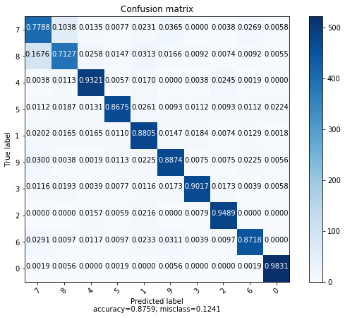

```python
clf = DecisionTreeClassifier(criterion="entropy", random_state=42)
clf.fit(train_set_30.iloc[:,0:2303], train_set_30['target'])
y_pred = clf.predict(test_set_30.iloc[:, 0:2303])
conf_mat = confusion_matrix(test_set_30["target"], y_pred)
print(classification_report(test_set_30["target"], y_pred))
plot_confusion_matrix(conf_mat, target_names=test_set_30['target'].unique())
```

```
              precision    recall  f1-score   support

           0       0.60      0.64      0.62       793
           1       0.60      0.60      0.60       795
           2       0.89      0.91      0.90       807
           3       0.90      0.84      0.87       808
           4       0.82      0.76      0.79       806
           5       0.85      0.83      0.84       787
           6       0.92      0.90      0.91       761
           7       0.88      0.93      0.90       796
           8       0.83      0.83      0.83       782
           9       0.91      0.94      0.92       785

    accuracy                           0.82      7920
   macro avg       0.82      0.82      0.82      7920
weighted avg       0.82      0.82      0.82      7920
```

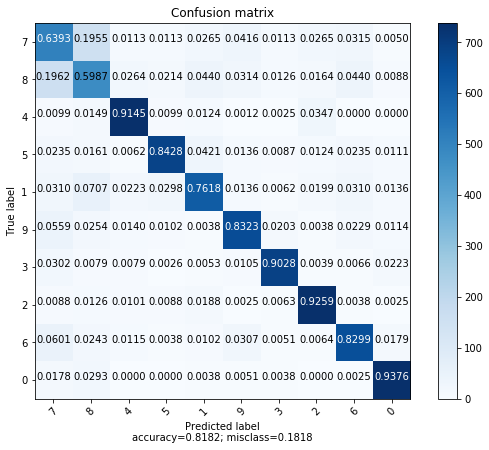

```python
clf = DecisionTreeClassifier(criterion="entropy", random_state=42)
clf.fit(train_set_70.iloc[:,0:2303], train_set_70['target'])
y_pred = clf.predict(test_set_70.iloc[:, 0:2303])
conf_mat = confusion_matrix(test_set_70["target"], y_pred)
print(classification_report(test_set_70["target"], y_pred))
plot_confusion_matrix(conf_mat, target_names=test_set_70['target'].unique())
```

For example, decision trees are a nonparametric machine learning algorithm that is very flexible and is subject to overfitting training data. This problem can be addressed by pruning a tree after it has learned in order to remove some of the detail it has picked up. Overfitting is such a problem because the evaluation of machine learning algorithms on training data is different from the evaluation we actually care the most about, namely how well the algorithm performs on unseen data. There are two important techniques that you can use when evaluating machine learning algorithms to limit overfitting: -Use a resampling technique to estimate model accuracy. -Hold back a validation dataset. As we previously resampled our dataset, even with a small training set, we managed to limit our overfitting. By pruning our Decision Tree, we avoided having our model memorize the training set with too much details. By these methods, our classifier generalize easily.

# FineTuning model

```
              precision    recall  f1-score   support

           0       0.67      0.59      0.63       335
           1       0.58      0.61      0.59       350
           2       0.74      0.86      0.80       339
           3       0.91      0.74      0.82       332
           4       0.73      0.72      0.72       324
           5       0.70      0.83      0.76       308
           6       0.86      0.82      0.84       338
           7       0.95      0.87      0.91       316
           8       0.88      0.78      0.83       322
           9       0.84      0.96      0.90       336

    accuracy                           0.78      3300
   macro avg       0.79      0.78      0.78      3300
weighted avg       0.78      0.78      0.78      3300
```

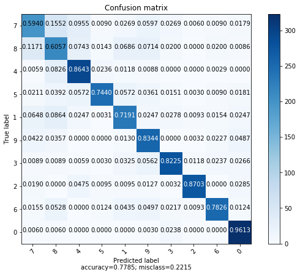

```python
clf = DecisionTreeClassifier(random_state=42, min_samples_leaf=50)
clf.fit(train_set.iloc[:,0:2303], train_set['target'])
y_pred = clf.predict(test_set.iloc[:, 0:2303])
conf_mat = confusion_matrix(test_set["target"], y_pred)
print(classification_report(test_set["target"], y_pred))
plot_confusion_matrix(conf_mat, target_names=test_set['target'].unique())
```

```
              precision    recall  f1-score   support

           0       0.70      0.51      0.59       335
           1       0.46      0.75      0.57       350
           2       0.90      0.89      0.90       339
           3       0.86      0.87      0.87       332
           4       0.92      0.77      0.84       324
           5       0.93      0.80      0.86       308
           6       0.94      0.86      0.89       338
           7       0.97      0.96      0.96       316
           8       0.77      0.79      0.78       322
           9       0.97      0.98      0.98       336

    accuracy                           0.82      3300
   macro avg       0.84      0.82      0.82      3300
weighted avg       0.84      0.82      0.82      3300
```

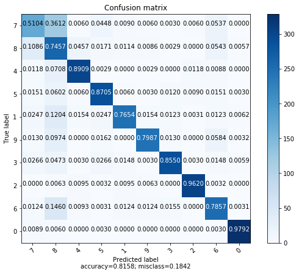

```python
clf = DecisionTreeClassifier(random_state=42, max_depth= 10)
clf.fit(train_set.iloc[:,0:2303], train_set['target'])
y_pred = clf.predict(test_set.iloc[:, 0:2303])
conf_mat = confusion_matrix(test_set["target"], y_pred)
print(classification_report(test_set["target"], y_pred))
plot_confusion_matrix(conf_mat, target_names=test_set['target'].unique())
```

```
              precision    recall  f1-score   support

           0       0.66      0.67      0.66       335
           1       0.57      0.62      0.60       350
           2       0.92      0.86      0.89       339
           3       0.87      0.86      0.87       332
           4       0.86      0.73      0.79       324
           5       0.72      0.86      0.79       308
           6       0.89      0.84      0.86       338
           7       0.95      0.92      0.93       316
           8       0.83      0.85      0.84       322
           9       0.93      0.95      0.94       336

    accuracy                           0.81      3300
   macro avg       0.82      0.82      0.82      3300
weighted avg       0.82      0.81      0.82      3300
```

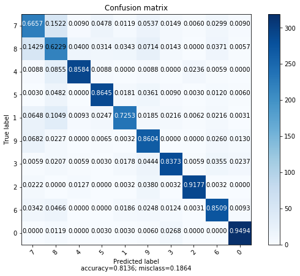

```python
clf = DecisionTreeClassifier(random_state=42, min_samples_split= 100)
clf.fit(train_set.iloc[:,0:2303], train_set['target'])
y_pred = clf.predict(test_set.iloc[:, 0:2303])
conf_mat = confusion_matrix(test_set["target"], y_pred)
print(classification_report(test_set["target"], y_pred))
plot_confusion_matrix(conf_mat, target_names=test_set['target'].unique())
```

```
Best params for accuracy_score
{'criterion': 'entropy', 'max_depth': 25, 'max_features': 200, 'min_samples_split': 10}
              precision    recall  f1-score   support

           0       0.75      0.79      0.77       335
           1       0.72      0.73      0.73       350
           2       0.94      0.93      0.93       339
           3       0.93      0.94      0.93       332
           4       0.87      0.83      0.85       324
           5       0.89      0.91      0.90       308
           6       0.93      0.93      0.93       338
           7       0.95      0.98      0.96       316
           8       0.93      0.85      0.89       322
           9       0.97      0.98      0.98       336

    accuracy                           0.89      3300
   macro avg       0.89      0.89      0.89      3300
weighted avg       0.89      0.89      0.89      3300
```

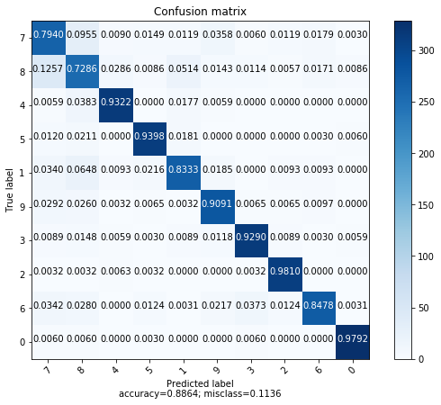

```
GridSearchCV(cv=StratifiedKFold(n_splits=10, random_state=None, shuffle=False),
             error_score='raise-deprecating',
             estimator=DecisionTreeClassifier(class_weight=None,
                                              criterion='gini', max_depth=None,
                                              max_features=None,
                                              max_leaf_nodes=None,
                                              min_impurity_decrease=0.0,
                                              min_impurity_split=None,
                                              min_samples_leaf=1,
                                              min_samples_split=2,
                                              min_weight_fraction_leaf=0.0,
                                              pr...
             param_grid={'criterion': ['gini', 'entropy'],
                         'max_depth': [3, 5, 15, 25],
                         'max_features': [10, 20, 30, 50, 100, 200],
                         'min_samples_split': [10, 20, 50, 100]},
             pre_dispatch='2*n_jobs', refit='accuracy_score',
             return_train_score=True,
             scoring={'accuracy_score': make_scorer(accuracy_score),
                      'precision_score': make_scorer(precision_score, average=macro),
                      'recall_score': make_scorer(recall_score, average=macro)},
             verbose=0)
```

```python
from sklearn.model_selection import train_test_split, GridSearchCV, StratifiedKFold
from sklearn.metrics import roc_curve, precision_recall_curve, auc, make_scorer, recall_score, accuracy_score, precision_score, confusion_matrix


scorers = {
    'precision_score': make_scorer(precision_score, average='macro'),
    'recall_score': make_scorer(recall_score, average='macro'),
    'accuracy_score': make_scorer(accuracy_score)
}

param_grid = {
    'criterion': ['gini', 'entropy'],
    'min_samples_split': [10, 20, 50, 100],
    'max_depth': [3, 5, 15, 25],
    'max_features': [10, 20, 30, 50, 100, 200]
}

def grid_search_wrapper(clf, X_train, X_test, Y_train, Y_test, refit_score='accuracy_score'):
    """
    https://towardsdatascience.com/fine-tuning-a-classifier-in-scikit-learn-66e048c21e65
    """
    skf = StratifiedKFold(n_splits=10)
    grid_search = GridSearchCV(clf, param_grid, scoring=scorers, refit=refit_score,
                           cv=skf, return_train_score=True, n_jobs=-1)
    grid_search.fit(X_train, Y_train)

    # make the predictions
    y_pred = grid_search.predict(X_test)

    print('Best params for {}'.format(refit_score))
    print(grid_search.best_params_)

    conf_mat = confusion_matrix(Y_test, y_pred)
    print(classification_report(Y_test, y_pred))
    plot_confusion_matrix(conf_mat, target_names=Y_test.unique())
    return grid_search

clf = DecisionTreeClassifier(random_state=42)
grid_search_wrapper(clf, train_set.iloc[:,0:2303], test_set.iloc[:, 0:2303], train_set['target'], test_set["target"])
```

# Research Question - Penalize DecisionTree for Imbalanced data

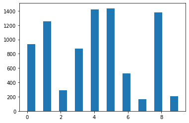

```python
plt.hist(train_real_set['target'], bins='auto')
```

```python
train_real_set['target'].value_counts()
```

```
5    1436
4    1422
8    1378
1    1252
0     937
3     874
6     524
2     290
9     204
7     165
Name: target, dtype: int64
```

## without penalisation

```
              precision    recall  f1-score   support

           0       0.78      0.74      0.76       473
           1       0.75      0.82      0.78       608
           2       0.81      0.81      0.81       130
           3       0.90      0.87      0.89       446
           4       0.90      0.86      0.88       678
           5       0.93      0.93      0.93       724
           6       0.91      0.90      0.91       256
           7       0.75      0.77      0.76        75
           8       0.90      0.92      0.91       692
           9       0.87      0.88      0.87        96

    accuracy                           0.86      4178
   macro avg       0.85      0.85      0.85      4178
weighted avg       0.86      0.86      0.86      4178
```

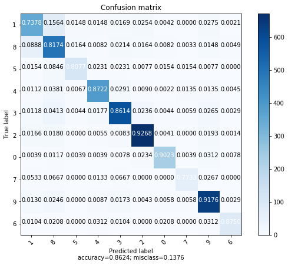

```python
clf = DecisionTreeClassifier(random_state=42, criterion =  'entropy', max_depth =  25, max_features = 200, min_samples_split = 10)
clf.fit(train_real_set.iloc[:,0:2303], train_real_set['target'])
y_pred = clf.predict(test_real_set.iloc[:, 0:2303])
conf_mat = confusion_matrix(test_real_set["target"], y_pred)
print(classification_report(test_real_set["target"], y_pred))
plot_confusion_matrix(conf_mat, target_names=test_real_set['target'].unique())
```

## With penalisation

```
              precision    recall  f1-score   support

           0       0.71      0.70      0.71       473
           1       0.76      0.78      0.77       608
           2       0.69      0.83      0.76       130
           3       0.88      0.88      0.88       446
           4       0.86      0.85      0.85       678
           5       0.94      0.90      0.92       724
           6       0.88      0.89      0.89       256
           7       0.78      0.87      0.82        75
           8       0.93      0.91      0.92       692
           9       0.83      0.92      0.87        96

    accuracy                           0.85      4178
   macro avg       0.83      0.85      0.84      4178
weighted avg       0.85      0.85      0.85      4178
```

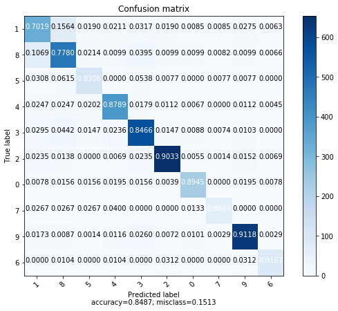

```python
class_weights = {'0': 1.53,'1': 1.15,'2': 4.95 ,'3': 1.64,'4': 1.01,'5': 1,'6': 2.74,'7': 8.7,'8': 1.04,'9': 7.04}

train_real_set['target'] = train_real_set['target'].astype(str)
test_real_set['target'] = test_real_set['target'].astype(str)
clf = DecisionTreeClassifier(random_state=42, criterion =  'entropy', max_depth =  25, max_features = 200, min_samples_split = 10, class_weight = class_weights)
clf.fit(train_real_set.iloc[:,0:2303], train_real_set['target'])
y_pred = clf.predict(test_real_set.iloc[:, 0:2303])
conf_mat = confusion_matrix(test_real_set["target"], y_pred)
print(classification_report(test_real_set["target"], y_pred))
plot_confusion_matrix(conf_mat, target_names=test_real_set['target'].unique())
```

Penalizing model doesn't improve model accuracy whereas resampling dataset improves.

# Check Overfit with penalization

```
              precision    recall  f1-score   support

           0       0.57      0.63      0.60      1118
           1       0.67      0.66      0.66      1452
           2       0.68      0.72      0.70       333
           3       0.92      0.81      0.86      1083
           4       0.78      0.83      0.80      1616
           5       0.90      0.85      0.87      1731
           6       0.88      0.81      0.84       629
           7       0.57      0.66      0.61       176
           8       0.85      0.85      0.85      1651
           9       0.68      0.66      0.67       238

    accuracy                           0.78     10027
   macro avg       0.75      0.75      0.75     10027
weighted avg       0.78      0.78      0.78     10027
```

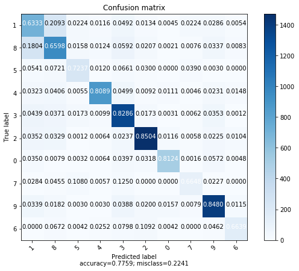

```python
clf = DecisionTreeClassifier(random_state=42, criterion =  'entropy', max_depth =  25, max_features = 200, min_samples_split = 10)
clf.fit(train_real_set_70.iloc[:,0:2303], train_real_set_70['target'])
y_pred = clf.predict(test_real_set_70.iloc[:, 0:2303])
conf_mat = confusion_matrix(test_real_set_70["target"], y_pred)
print(classification_report(test_real_set_70["target"], y_pred))
plot_confusion_matrix(conf_mat, target_names=test_real_set_70['target'].unique())
```

## With penalisation

```
              precision    recall  f1-score   support

           0       0.60      0.65      0.62      1118
           1       0.64      0.66      0.65      1452
           2       0.73      0.79      0.76       333
           3       0.88      0.82      0.85      1083
           4       0.77      0.81      0.79      1616
           5       0.91      0.85      0.87      1731
           6       0.84      0.80      0.82       629
           7       0.66      0.68      0.67       176
           8       0.87      0.84      0.85      1651
           9       0.70      0.79      0.74       238

    accuracy                           0.78     10027
   macro avg       0.76      0.77      0.76     10027
weighted avg       0.78      0.78      0.78     10027
```

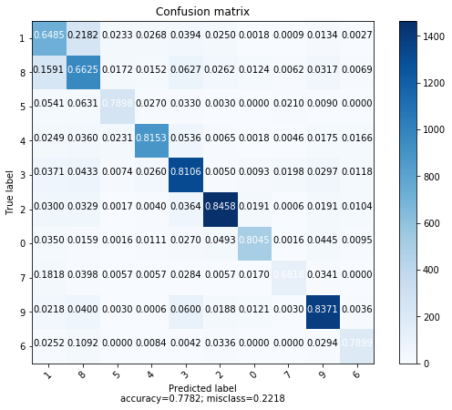

```python
class_weights = {'0': 1.53,'1': 1.15,'2': 4.95 ,'3': 1.64,'4': 1.01,'5': 1,'6': 2.74,'7': 8.7,'8': 1.04,'9': 7.04}

train_real_set_70['target'] = train_real_set_70['target'].astype(str)
test_real_set_70['target'] = test_real_set_70['target'].astype(str)
clf = DecisionTreeClassifier(random_state=42, criterion =  'entropy', max_depth =  25, max_features = 200, min_samples_split = 10, class_weight = class_weights)
clf.fit(train_real_set_70.iloc[:,0:2303], train_real_set_70['target'])
y_pred = clf.predict(test_real_set_70.iloc[:, 0:2303])
conf_mat = confusion_matrix(test_real_set_70["target"], y_pred)
print(classification_report(test_real_set_70["target"], y_pred))
plot_confusion_matrix(conf_mat, target_names=test_real_set_70['target'].unique())
```

for a train/test ratio of 21/79, penalization doesn't improve a lot the accuracy and doesn't help to avoid overfitting.